# Weather Prediction

**Corrections Made:**

1. I switched my plot over to ggplot from base R.
2. Added details to my Data Set information.
3. I put a fourth tab to keep what I did wrong in my first attempt. No explainations were written though as to why this was incorrect.
4. I redid the entire `Summary` and `Details To Look At sections` since I had to change my x-variable.

### Analysis

#### Summary

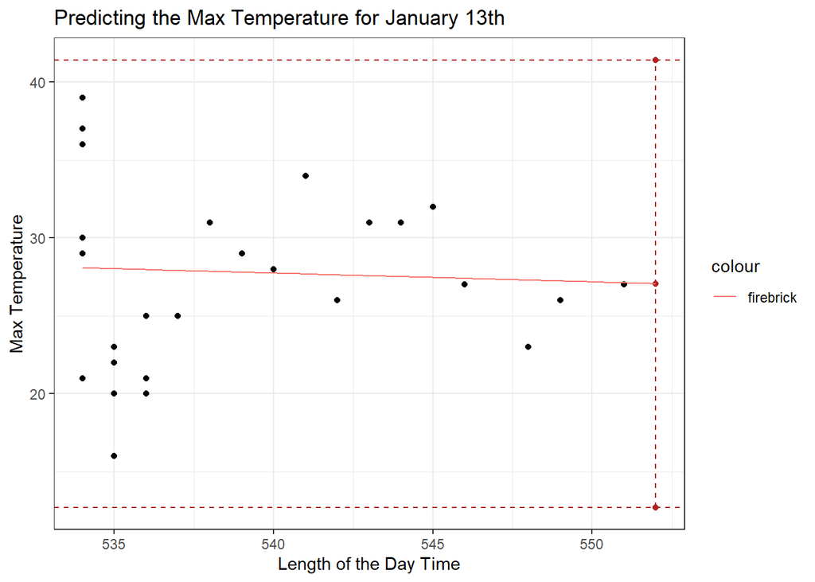

```r
my.lm <- lm(MaxTemp ~ TimeLength, data = Weather)
my.lm.co <- my.lm$coefficients
mylines <- predict(my.lm, data.frame(TimeLength = 552), interval = "prediction")

Weather %>%
  ggplot(aes(y = MaxTemp, x = TimeLength)) +
  geom_point() +
  geom_point(aes(x = 552, y = mylines[2]), color = "firebrick") +
  geom_point(aes(x = 552, y = mylines[1]), color = "firebrick") +
  geom_point(aes(x = 552, y = mylines[3]), color = "firebrick") +
  geom_hline(aes(yintercept = mylines[2]), color = "firebrick", linetype = 2) +
  geom_hline(aes(yintercept = mylines[3]), color = "firebrick", linetype = 2) +
  geom_segment(aes(x=552, xend=552, y=mylines[2], yend=mylines[3]), color="firebrick", linetype = 2) + # mylines[2] lowend mylines[3] highend
  stat_function(fun = function(x) my.lm.co[1] + my.lm.co[2]*x,
                aes(color = "firebrick")) +
  labs(title = "Predicting the Max Temperature for January 13th",
        x = "Length of the Day Time",
        y = "Max Temperature") +
  theme_bw()
```

```r
  # theme(plot.title = element_text(hjust = 0.5),
  #       legend.position = c(0.85, .85)) +
  # scale_color_manual("",
  #                    values = c("black", "firebrick"),
  #                    labels = c("Regression Line", "Transformed Regression"))
```

In order to predict January 13th’s max temperature, I am using it’s length of day 552 minutes. I predict that January 13th’s max temperature will be $27.07^oF$. It could also potentially be anywhere from $12.72^oF$ to $41.43^oF$.

**Real Temperature**: The real temperature of January 13, 2020 was $28^oF$.

#### Details to Look At

In my test to try and predict the max temperature, I went to [Weather Underground](https://www.wunderground.com/history/daily/KRXE) for my information. Since I needed a variable that would be known and never changes, I decided to use the length of daylight for January 13th. January 13th’s length of daylight is ((9 hours * 60) + 12 minutes) = 552 minutes.

```r
# Perform the Test
mylm <- lm(MaxTemp ~ TimeLength, data = Weather)
pander(summary(mylm))
```

|  | Estimate | Std. Error | t value | Pr(>\|t\|) |
| --- | --- | --- | --- | --- |
| **(Intercept)** | 58.03 | 120.5 | 0.4817 | 0.6339 |
| **TimeLength** | -0.05607 | 0.2237 | -0.2507 | 0.804 |

Fitting linear model: MaxTemp ~ TimeLength

| Observations | Residual Std. Error | $R^2$ | Adjusted $R^2$ |
| --- | --- | --- | --- |
| 29 | 6.211 | 0.002322 | -0.03463 |

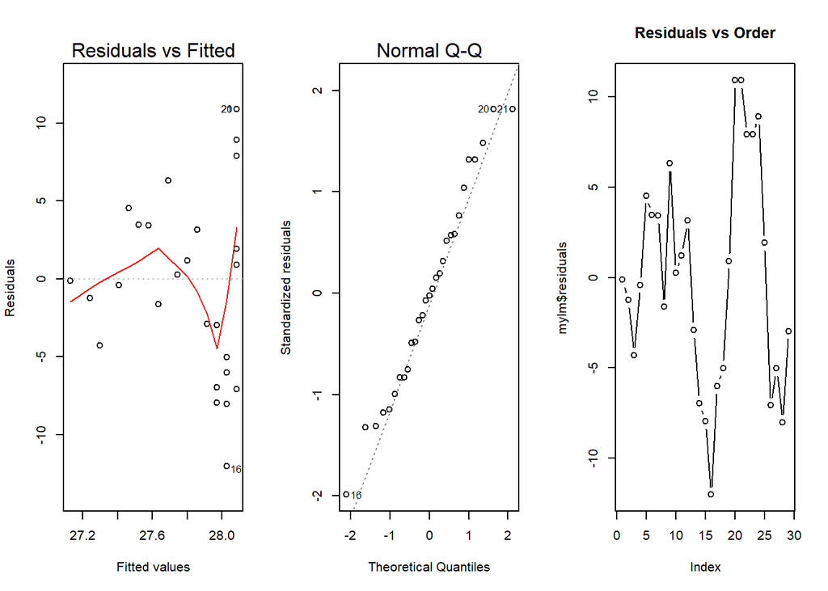

```r
# Check Assumptions
par(mfrow=c(1,3))
plot(mylm, which=1:2)
plot(mylm$residuals, type = "b", main = "Residuals vs Order")
```

```r
#plot(mylm, which = 1)
# qqPlot(mylm$residuals, main = "Q-Q Plot of Residuals", id = FALSE)
```

The results of this prediction is insignificant. I am looking at both the $p$-values of Intercept,`0.634`, and TimeLength, `0.804`, because a temperature of 0 is feasible to have. Even my $R^2$ value shows I am explaining a measly `0.002` of the data points variability from the average $y$-value, $\bar{Y}$ or the average max temperature, using my regression line. Each data point is varying `6.21` degrees from the regression line.

```r
pander(predict(my.lm, data.frame(TimeLength = 552), interval = "prediction"))
```

| fit | lwr | upr |
| --- | --- | --- |
| 27.07 | 12.72 | 41.43 |

The prediction for January 13, 2020 will be $27.07^oF$, but it could also potentially be anywhere from $12.72^oF$ to $41.43^oF$.

#### Data Set

My data comes from [Weather Underground](https://www.wunderground.com/history/daily/KRXE) for my information. I pulled data from the 12th of January 2020 back to the 15th of December 2019. I pulled information on the low temperature, average temperature, the dew point, sea pressure, and the length of day time.

1. Day (Date from which the information was gathered)
2. MaxTemp (Max temperature of the day in Fahrenheit)
3. LowTemp (Lowest temperature of the day in Fahrenheit)
4. AvgTemp (Average temperature of the day in Fahrenheit)
5. Dew (Dew point for the day)
6. SeaPressure (As name implies, the sea pressure)
7. TimeLength (How long the sun was out by mintures)
8. TotalAvg (I added Low, Avg, Dew, Pressure, and Total together and divided by five to get this column)

```r
datatable(Weather)
```

|  | Day | MaxTemp | LowTemp | AvgTemp | Dew | SeaPressure | TimeLength | TotalAvg |
| --- | --- | --- | --- | --- | --- | --- | --- | --- |
| 1 | 12-Jan-20 | 27 | 21 | 13 | 21 | 30.05 | 551 | 127.21 |
| 2 | 11-Jan-20 | 26 | 21 | 23.63 | 19.25 | 25.08 | 549 | 127.592 |
| 3 | 10-Jan-20 | 23 | -5 | 10.56 | 3.18 | 25.3 | 548 | 116.408 |
| 4 | 9-Jan-20 | 27 | 21 | 25.34 | 22.18 | 25.07 | 546 | 127.918 |
| 5 | 8-Jan-20 | 32 | 18 | 25.42 | 21.08 | 24.97 | 545 | 126.894 |
| 6 | 7-Jan-20 | 31 | 25 | 27.81 | 23.35 | 25.36 | 544 | 129.104 |
| 7 | 6-Jan-20 | 31 | 19 | 23.55 | 19.05 | 25.45 | 543 | 126.01 |
| 8 | 5-Jan-20 | 26 | 9 | 21.39 | 17.76 | 25.43 | 542 | 123.116 |
| 9 | 4-Jan-20 | 34 | 8 | 17.77 | 13.73 | 25.43 | 541 | 121.186 |
| 10 | 3-Jan-20 | 28 | 16 | 24 | 20.12 | 25.37 | 540 | 125.098 |

[output cut: 19 more lines]

#### Incorrect 1st Attempt

##### Summary

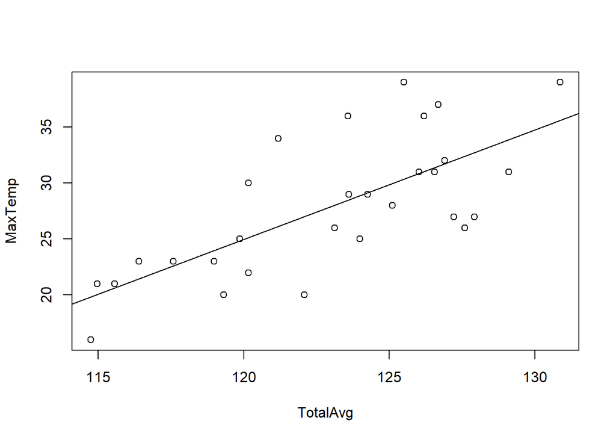

```r
#Plot the Regression Line
mylm1 <- lm(MaxTemp ~ TotalAvg, data = Weather)

plot(MaxTemp ~ TotalAvg, data = Weather)
abline(mylm1)
```

$$\underbrace{\hat{Y}_i}_\text{Max Temperature} = \underbrace{b_0}_\text{-92.4557} + \underbrace{b_1}_\text{ 0.9784} \overbrace{X_i}^\text{16+21+19+29.85+((9*60)+11))/5)}$$

Here is what I predict January 13th max temperature will be $32.16 ^oF$.

##### Incorrect 1st Details

In my test to try and predict the max temperature, I went to [Weather Underground](https://www.wunderground.com/history/daily/KRXE) for my information. To get my X variable I added low temperature, averager temperature, the dew point, sea pressure, and the length of day time all together and divided them by five.

```r
# Perform the Test
mylm1 <- lm(MaxTemp ~ TotalAvg, data = Weather)
pander(summary(mylm1))
```

|  | Estimate | Std. Error | t value | Pr(>\|t\|) |
| --- | --- | --- | --- | --- |
| **(Intercept)** | -92.46 | 22.68 | -4.077 | 0.0003609 |
| **TotalAvg** | 0.9784 | 0.1843 | 5.308 | 1.334e-05 |

Fitting linear model: MaxTemp ~ TotalAvg

| Observations | Residual Std. Error | $R^2$ | Adjusted $R^2$ |
| --- | --- | --- | --- |
| 29 | 4.35 | 0.5106 | 0.4925 |

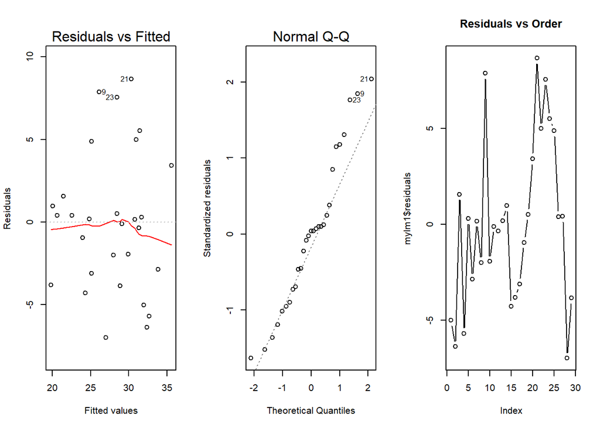

```r
# Check Assumptions
par(mfrow=c(1,3))
plot(mylm1, which=1:2)
plot(mylm1$residuals, type = "b", main = "Residuals vs Order")
```

```r
#plot(mylm, which = 1)
# qqPlot(mylm$residuals, main = "Q-Q Plot of Residuals", id = FALSE)
```

```r
#Prediction

pander(-92.4557 + 0.9784*((16+21+19+29.85+((9*60)+11))/5))
```

*32.16*